# Quantile Regression for Population Health Analysis

Arash Ardalan

## 0.1 1. Overview

This notebook demonstrates a clean, reproducible approach to analysing health-related outcomes using **quantile regression**. Unlike mean regression, quantile regression allows us to examine how associations differ across the **entire distribution** of an outcome (e.g. BMI), which is particularly important in population health research.

### 0.1.1 Data disclaimer

The dataset used in this analysis is an **anonymised subset (n = 1000)** derived from a larger adolescent health study. Only a limited set of anthropometric, demographic, and family-level variables were retained. All identifiers were removed, and the data is used solely for demonstrating analytical workflows.

## 0.2 2. Libraries

```r
library(tidyverse)
library(ggplot2)
library(quantreg)
library(broom)
```

## 0.3 3. Load data

```r
df <- read.csv("C:\\Users\\Arash\\OneDrive - Royal Holloway University of London\\Desktop\\QR_2025\\health_sample_data.csv")

glimpse(df)
```

```
## Rows: 1,000
## Columns: 13
## $ bmi                 <dbl> 17.55562, 20.25028, 22.68724, 21.27219, 24.21742, …
## $ body_fat            <dbl> 7.10, 24.40, 31.08, 15.30, 23.40, 36.60, 18.10, 26…
## $ waist_circ          <dbl> 70.0, 72.0, 68.0, 79.0, 92.0, 74.8, 63.3, 93.0, 64…
## $ hip_circ            <dbl> 87.0, 88.0, 95.0, 71.0, 105.0, 96.2, 82.7, 105.0, …
## $ arm_circ            <dbl> 23.0, 21.5, 24.0, 20.0, 29.0, 26.5, 21.2, 29.0, 19…
## $ age                 <dbl> 17.67123, 17.89315, 15.36986, 14.83562, 17.36438, …
## $ Gender              <chr> "Boys", "Girls", "Girls", "Girls", "Boys", "Girls"…
## $ city                <chr> "Jahrom", "Shiraz", "Jahrom", "Shiraz", "Shiraz", …
## $ muscle_thickness    <dbl> 8.000000, 11.050000, 17.666667, NA, 17.666667, 20.…
## $ waist_hip_avg       <dbl> 60.00000, 60.50000, 62.33333, 56.66667, 75.33333, …
## $ parent_obese_father <chr> "No", "No", "No", "No", "No", "No", "No", "No", "N…
## $ parent_obese_mother <chr> "No", "No", "No", "No", "Yes", "No", "No", "No", "…
## $ activity            <chr> "Yes", "No", "Yes", "Yes", "No", "Yes", "Yes", "Ye…
```

```r
summary(df)
```

```
##       bmi           body_fat       waist_circ        hip_circ
##  Min.   :14.40   Min.   : 5.00   Min.   : 55.00   Min.   : 70.00
##  1st Qu.:19.12   1st Qu.:14.47   1st Qu.: 69.00   1st Qu.: 87.00
##  Median :21.10   Median :23.40   Median : 75.00   Median : 91.00
##  Mean   :21.95   Mean   :23.17   Mean   : 76.71   Mean   : 92.51
##  3rd Qu.:23.95   3rd Qu.:30.60   3rd Qu.: 83.00   3rd Qu.: 97.00
##  Max.   :41.49   Max.   :55.10   Max.   :123.00   Max.   :124.00
##                                  NA's   :4        NA's   :5
##     arm_circ          age           Gender              city
##  Min.   :14.50   Min.   :13.93   Length:1000        Length:1000
##  1st Qu.:22.00   1st Qu.:15.30   Class :character   Class :character
##  Median :24.30   Median :15.96   Mode  :character   Mode  :character
##  Mean   :24.84   Mean   :16.07
##  3rd Qu.:27.00   3rd Qu.:16.81
##  Max.   :39.00   Max.   :20.67
##  NA's   :8
##  muscle_thickness waist_hip_avg   parent_obese_father parent_obese_mother
##  Min.   : 5.417   Min.   :49.33   Length:1000         Length:1000
##  1st Qu.:11.833   1st Qu.:59.57   Class :character    Class :character
##  Median :15.667   Median :63.37   Mode  :character    Mode  :character
##  Mean   :17.562   Mean   :64.67
##  3rd Qu.:21.600   3rd Qu.:68.40
##  Max.   :60.750   Max.   :94.67
##  NA's   :3        NA's   :11
##    activity
##  Length:1000
##  Class :character
##  Mode  :character
##
##
##
##
```

### 0.3.1 Basic cleaning and typing

```r
df <- df %>%
  mutate(
    Gender = factor(Gender),
    city = factor(city),
    activity = factor(activity),
    parent_obese_father = factor(parent_obese_father),
    parent_obese_mother = factor(parent_obese_mother)
  ) %>%
  filter(
    is.finite(bmi),
    is.finite(body_fat),
    is.finite(age)
  )
```

### 0.3.2 Missingness check

```r
miss_rate <- sapply(df, function(x) mean(is.na(x)))
miss_rate
```

```
##                 bmi            body_fat          waist_circ            hip_circ
##               0.000               0.000               0.004               0.005
##            arm_circ                 age              Gender                city
##               0.008               0.000               0.000               0.000
##    muscle_thickness       waist_hip_avg parent_obese_father parent_obese_mother
##               0.003               0.011               0.000               0.000
##            activity
##               0.002
```

## 0.4 4. Exploratory Data Analysis (EDA)

### 0.4.1 4.1 BMI distribution

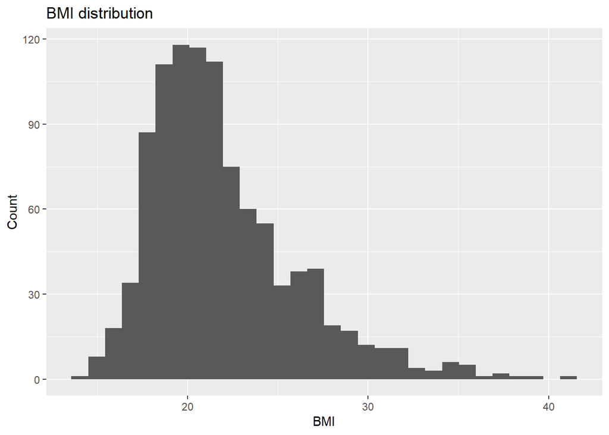

```r
ggplot(df, aes(x = bmi)) +
  geom_histogram(bins = 30) +
  labs(title = "BMI distribution", x = "BMI", y = "Count")
```

### 0.4.2 4.2 BMI distribution by gender

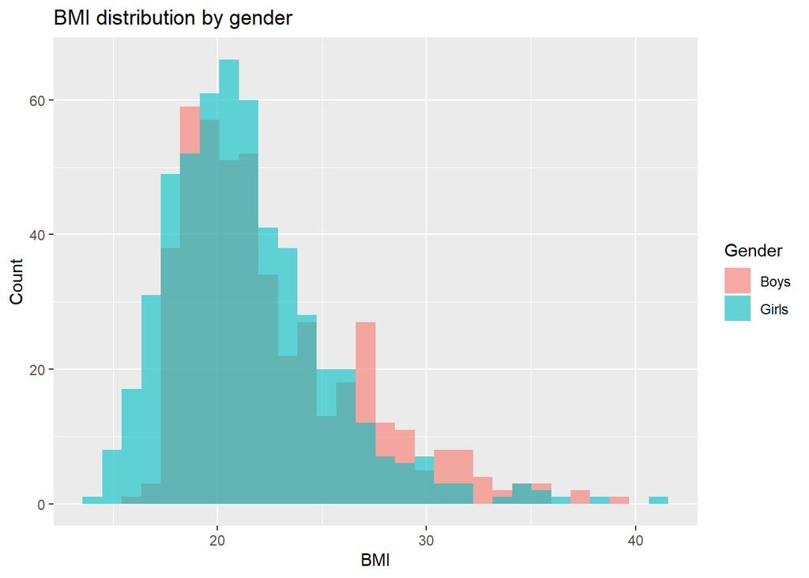

```r
ggplot(df, aes(x = bmi, fill = Gender)) +
  geom_histogram(bins = 30, alpha = 0.6, position = "identity") +
  labs(title = "BMI distribution by gender", x = "BMI", y = "Count")
```

### 0.4.3 4.3 Summary statistics by gender

```r
df %>%
group_by(Gender) %>%
summarise(
n = n(),
bmi_mean = mean(bmi, na.rm = TRUE),
bmi_sd = sd(bmi, na.rm = TRUE),
bf_mean = mean(body_fat, na.rm = TRUE),
bf_sd = sd(body_fat, na.rm = TRUE),
age_mean = mean(age, na.rm = TRUE),
.groups = "drop"
)
```

```
## # A tibble: 2 × 7
##   Gender     n bmi_mean bmi_sd bf_mean bf_sd age_mean
##   <fct>  <int>    <dbl>  <dbl>   <dbl> <dbl>    <dbl>
## 1 Boys     461     22.6   4.22    17.2  8.53     16.2
## 2 Girls    539     21.4   3.88    28.2  9.12     16.0
```

### 0.4.4 4.4 Relationship plots

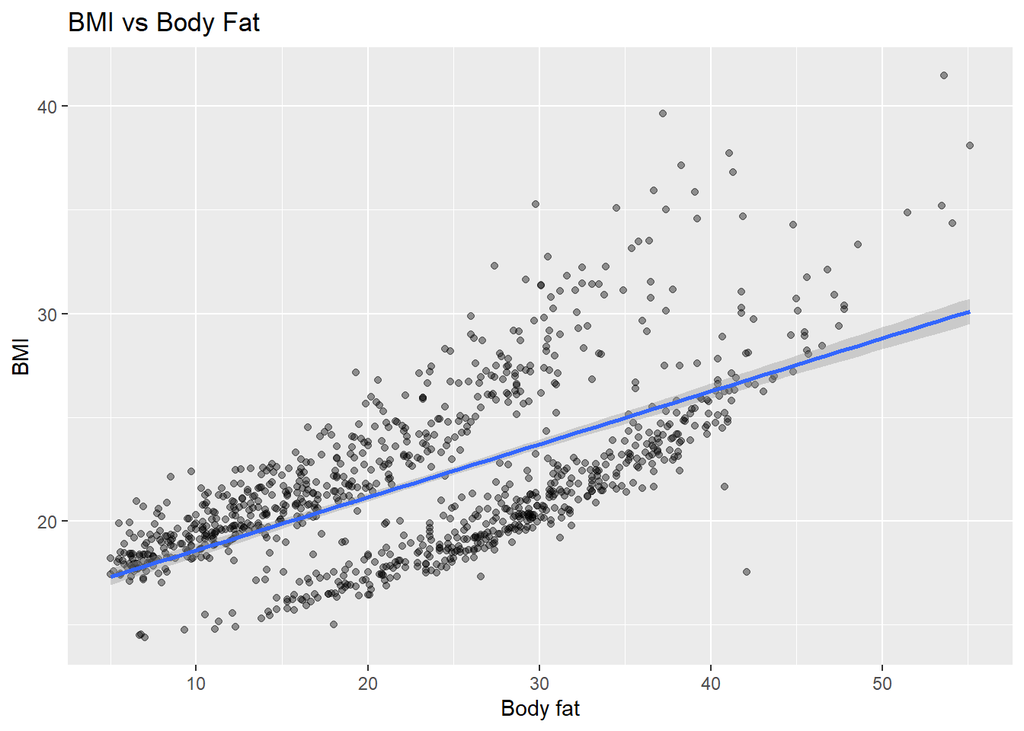

```r
ggplot(df, aes(x = body_fat, y = bmi)) +
geom_point(alpha = 0.4) +
geom_smooth(method = "lm", se = TRUE) +
labs(
title = "BMI vs Body Fat",
x = "Body fat",
y = "BMI"
)
```

```r
ggplot(df, aes(x = muscle_thickness, y = bmi, colour = Gender)) +
geom_point(alpha = 0.4) +
geom_smooth(method = "lm", se = TRUE) +
labs(
title = "BMI vs Muscle Thickness (by gender)",
x = "Muscle thickness",
y = "BMI"
)
```

[figure not shown]

We focus on a small, interpretable set of predictors to emphasise clarity and practical insight rather than model complexity.

## 0.6 5. Quantile Regression

### 0.6.1 5.1 Model specification

```r
taus <- c(0.1, 0.25, 0.5, 0.75, 0.9)

formula_qr <- bmi ~ body_fat + muscle_thickness + waist_hip_avg +
  parent_obese_father + parent_obese_mother +
  age + Gender + city + activity
```

### 0.6.2 5.2 Fit quantile regression models

```r
qr_fit <- rq(formula_qr, tau = taus, data = df)
summary(qr_fit, se = "nid")
```

```
##
## Call: rq(formula = formula_qr, tau = taus, data = df)
##
## tau: [1] 0.1
##
## Coefficients:
##                        Value     Std. Error t value   Pr(>|t|)
## (Intercept)              2.56382   0.69073    3.71175   0.00022
## body_fat                 0.19927   0.00915   21.78290   0.00000
## muscle_thickness         0.06571   0.00880    7.46581   0.00000
## waist_hip_avg            0.19329   0.00976   19.79626   0.00000
## parent_obese_fatherYes   0.13087   0.19457    0.67261   0.50136
## parent_obese_motherYes   0.08416   0.08037    1.04724   0.29525
## age                      0.04685   0.03376    1.38768   0.16555
## GenderGirls             -3.12171   0.15287  -20.42061   0.00000
## cityShiraz              -0.05072   0.09768   -0.51923   0.60372
## activityYes              0.53837   0.15949    3.37568   0.00077
##
## Call: rq(formula = formula_qr, tau = taus, data = df)
##
## tau: [1] 0.25
##
## Coefficients:
##                        Value     Std. Error t value   Pr(>|t|)
## (Intercept)              4.23719   0.92971    4.55753   0.00001
## body_fat                 0.18960   0.00956   19.82279   0.00000
## muscle_thickness         0.07777   0.00981    7.92763   0.00000
## waist_hip_avg            0.19098   0.01238   15.42109   0.00000
## parent_obese_fatherYes   0.06152   0.12621    0.48743   0.62606
## parent_obese_motherYes   0.08738   0.11684    0.74790   0.45470
## age                     -0.00730   0.03824   -0.19101   0.84855
## GenderGirls             -3.14822   0.16290  -19.32610   0.00000
## cityShiraz               0.09851   0.08692    1.13328   0.25738
## activityYes              0.35120   0.18994    1.84895   0.06477
##
## Call: rq(formula = formula_qr, tau = taus, data = df)
##
## tau: [1] 0.5
##
## Coefficients:
```

[output cut: 30 more lines]

```
##
## tau: [1] 0.9
##
## Coefficients:
##                        Value    Std. Error t value  Pr(>|t|)
## (Intercept)            -1.34470  1.57760   -0.85237  0.39422
## body_fat                0.11372  0.01767    6.43486  0.00000
## muscle_thickness        0.18326  0.01462   12.53344  0.00000
## waist_hip_avg           0.25751  0.02387   10.78597  0.00000
## parent_obese_fatherYes  0.04733  0.22828    0.20731  0.83581
## parent_obese_motherYes -0.11050  0.12231   -0.90337  0.36655
## age                     0.14433  0.06884    2.09661  0.03629
## GenderGirls            -1.12431  0.27335   -4.11306  0.00004
## cityShiraz              0.83650  0.16938    4.93844  0.00000
## activityYes             0.52206  0.27989    1.86521  0.06245
```

### 0.6.3 5.3 Median regression (tau = 0.5)

```r
qr_med <- rq(formula_qr, tau = 0.5, data = df)
summary(qr_med, se = "nid")
```

```
##
## Call: rq(formula = formula_qr, tau = 0.5, data = df)
##
## tau: [1] 0.5
##
## Coefficients:
##                        Value     Std. Error t value   Pr(>|t|)
## (Intercept)              1.89014   1.03840    1.82024   0.06903
## body_fat                 0.17266   0.01372   12.58012   0.00000
## muscle_thickness         0.09580   0.01330    7.20556   0.00000
## waist_hip_avg            0.23019   0.01511   15.22932   0.00000
## parent_obese_fatherYes   0.03424   0.12010    0.28512   0.77562
## parent_obese_motherYes   0.17634   0.12408    1.42126   0.15556
## age                      0.01462   0.04075    0.35876   0.71986
## GenderGirls             -2.63670   0.22464  -11.73758   0.00000
## cityShiraz               0.22702   0.09633    2.35670   0.01864
## activityYes              0.38086   0.10376    3.67070   0.00026
```

## 0.7 6. Coefficient trends across quantiles

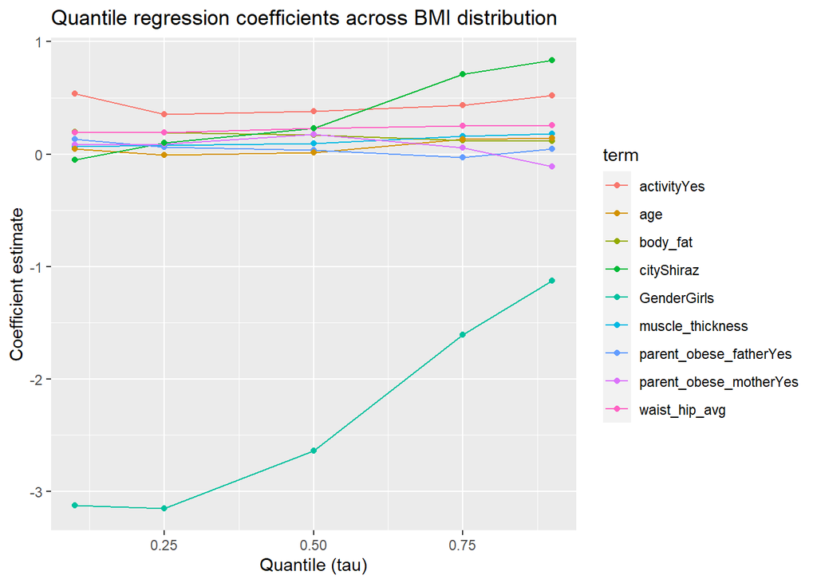

```r
coef_df <- tidy(qr_fit) %>%
filter(term != "(Intercept)")

ggplot(coef_df, aes(x = tau, y = estimate, group = term, colour = term)) +
geom_line() +
geom_point() +
labs(
title = "Quantile regression coefficients across BMI distribution",
x = "Quantile (tau)",
y = "Coefficient estimate"
)
```

```r
key_terms <- c(
"body_fat",
"muscle_thickness",
"waist_hip_avg",
"parent_obese_fatherYes",
"parent_obese_motherYes"
)

coef_df_key <- coef_df %>%
filter(term %in% key_terms)
```

```r
qr_med <- rq(formula_qr, tau = 0.5, data = df)
summary(qr_med, se = "nid")
```

```
##
## Call: rq(formula = formula_qr, tau = 0.5, data = df)
##
## tau: [1] 0.5
##
## Coefficients:
##                        Value     Std. Error t value   Pr(>|t|)
## (Intercept)              1.89014   1.03840    1.82024   0.06903
## body_fat                 0.17266   0.01372   12.58012   0.00000
## muscle_thickness         0.09580   0.01330    7.20556   0.00000
## waist_hip_avg            0.23019   0.01511   15.22932   0.00000
## parent_obese_fatherYes   0.03424   0.12010    0.28512   0.77562
## parent_obese_motherYes   0.17634   0.12408    1.42126   0.15556
## age                      0.01462   0.04075    0.35876   0.71986
## GenderGirls             -2.63670   0.22464  -11.73758   0.00000
## cityShiraz               0.22702   0.09633    2.35670   0.01864
## activityYes              0.38086   0.10376    3.67070   0.00026
```

```r
coef_df <- tidy(qr_fit) %>%
  filter(term != "(Intercept)")
```

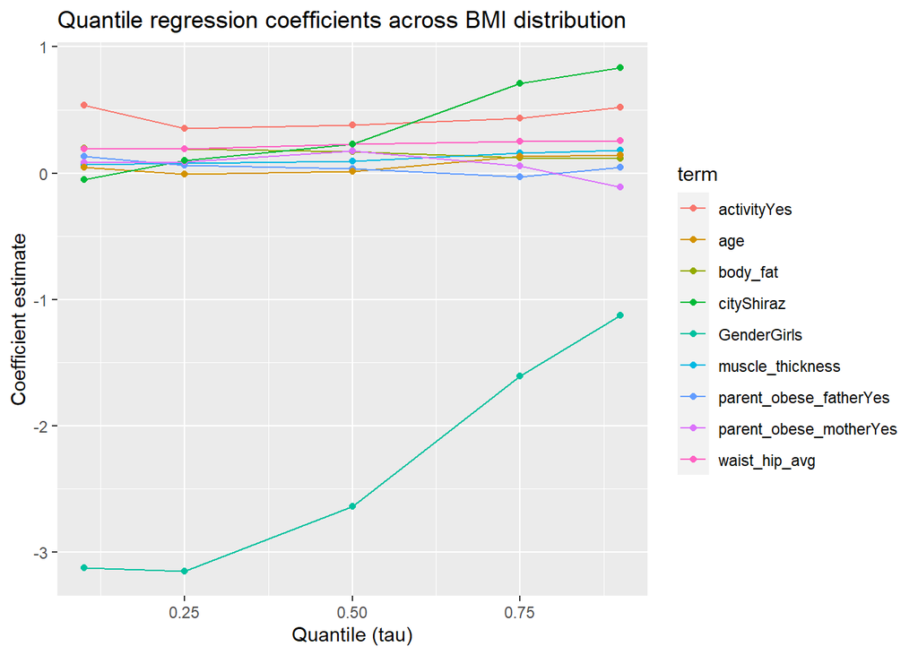

```r
ggplot(coef_df, aes(x = tau, y = estimate, group = term, color = term)) +
  geom_line() +
  geom_point() +
  labs(
    title = "Quantile regression coefficients across BMI distribution",
    x = "Quantile (tau)",
    y = "Coefficient estimate"
  )
```

## 0.8 7. Interpretation

```r
coef_df_key %>%
 select(tau, term, estimate) %>%
 pivot_wider(names_from = tau, values_from = estimate)
```

```
## # A tibble: 5 × 6
##   term                    `0.1` `0.25`  `0.5`  `0.75`   `0.9`
##   <chr>                   <dbl>  <dbl>  <dbl>   <dbl>   <dbl>
## 1 body_fat               0.199  0.190  0.173   0.120   0.114
## 2 muscle_thickness       0.0657 0.0778 0.0958  0.160   0.183
## 3 waist_hip_avg          0.193  0.191  0.230   0.253   0.258
## 4 parent_obese_fatherYes 0.131  0.0615 0.0342 -0.0293  0.0473
## 5 parent_obese_motherYes 0.0842 0.0874 0.176   0.0591 -0.110
```

**Interpretation guidance:**

- Increasing coefficients at higher quantiles indicate stronger associations among higher-BMI individuals.
- Differences across quantiles highlight heterogeneity that is not captured by mean regression.
- All results represent **associations**, not causal effects.

## 0.9 8. Logistic regression

```r
df <- df %>%
  mutate(high_bmi = factor(ifelse(bmi >= 25, "Yes", "No")))

glm_fit <- glm(
  high_bmi ~ body_fat + muscle_thickness + waist_hip_avg +
    parent_obese_father + parent_obese_mother +
    age + Gender + city + activity,
  family = binomial(link = "logit"),
  data = df
)

summary(glm_fit)
```

```
##
## Call:
## glm(formula = high_bmi ~ body_fat + muscle_thickness + waist_hip_avg +
##     parent_obese_father + parent_obese_mother + age + Gender +
##     city + activity, family = binomial(link = "logit"), data = df)
##
## Deviance Residuals:
##     Min       1Q   Median       3Q      Max
## -2.9504  -0.0785  -0.0138  -0.0017   3.2778
##
## Coefficients:
##                         Estimate Std. Error z value Pr(>|z|)
## (Intercept)            -43.29718    5.70671  -7.587 3.27e-14 ***
## body_fat                 0.24508    0.05545   4.420 9.89e-06 ***
## muscle_thickness         0.17529    0.03583   4.892 1.00e-06 ***
## waist_hip_avg            0.42579    0.06646   6.406 1.49e-10 ***
## parent_obese_fatherYes   0.08361    0.47990   0.174 0.861693
## parent_obese_motherYes  -0.65152    0.42696  -1.526 0.127018
## age                      0.12067    0.17781   0.679 0.497340
## GenderGirls             -3.25200    0.86464  -3.761 0.000169 ***
## cityShiraz               0.58254    0.40465   1.440 0.149974
## activityYes              1.30579    0.58491   2.232 0.025583 *
## ---
## Signif. codes:  0 '***' 0.001 '**' 0.01 '*' 0.05 '.' 0.1 ' ' 1
##
## (Dispersion parameter for binomial family taken to be 1)
##
##     Null deviance: 959.90  on 983  degrees of freedom
## Residual deviance: 214.13  on 974  degrees of freedom
##   (16 observations deleted due to missingness)
## AIC: 234.13
##
## Number of Fisher Scoring iterations: 8
```

## 0.10 9. Limitations and good practice

- Observational data do not support causal inference
- Potential unmeasured confounding and measurement error
- Results shown for methodological demonstration purposes

## 0.11 10. Conclusion

This project demonstrates an end-to-end, reproducible workflow for population health analysis using **quantile regression**, combining sound statistical practice with clear communication and ethical data handling.